# LabExperiment1

12 March 2018

# Lab Experiment 1: Single-species Population Growth

## Part II

Now that you and the class have grown populations of yeast in lab, it’s time to analyze and write up the experiment. The remaining parts of this first Laboratry Experiment will be to analyze the data and to write it up as a short paper by the end of the week.

The analysis will consist of three parts: (1) exploratory data analysis, (2) parameter estimation, and (3) model selection. Exploratory data analysis will have you explore your data in ways that you’ve prediously done with the Lecture Notebooks (e.g., plot per-capita growth rate against density) to directly relate your emipircal data to the theoretical work you’ve been doing. Next, parameter estimation is a process by which *free parameters* (i.e., parameters without numeric values such as $r$ and $\alpha$) are estimated. We will be using the simplest method, non-linear least squares estimates. You’re already familiar with linear least squares estimates used in linear regression, as $y = \beta _0 + \sum _{j = 1}^{n}\beta _j x_{j}$). In principle they are acheiving the saem goal, but there are subtle differences beyond the scope of this lab and course. Lastly, after you’ve finished parameterizing various density-dependent models, we seek to *compare across models* to determine which one best explains the data. But because highly non-linear functions with many free parameters will fit anything better, we use a framework that balances the amount of varaince explained by the model with its complexity (number of free parameters). In particular, we will use a common approach based on information criteria, called Akaike information criterion (AIC), as described in the Bonsall and Hassell chapter.

> “With four parameters I can fit an elephant, and with five I can make him wiggle his trunk.”  
> —John von Neumann, attributed by E. Fermi, as written by Freeman Dyson, no date

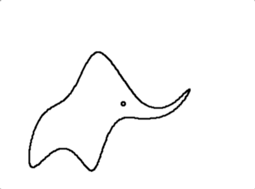

> (from [link](https://aapt.scitation.org/doi/10.1119/1.3254017))

After the analysis is finished, I ask that you write a small paper with an introduction, methods, results, and discussion. Below I go into the details of the analysis and paper.

### Analysis

#### Exploratory data analysis

I spent some time cleaning up your data to standardize it across groups, removed unimportant data, and only calculated the elapsed time for each group (your welcome :)). Normally, once data is entered, you practically **never** modify it to better keep track of your changes when you use software (e.g., using R you can import raw data, clean it up, resave it, and all of the steps will be documented). I exported the data as a .csv to be read in by R, download it and save it in a directory for “LabExperiment1” you create in the appropriate directory (i.e. “Private/LabExperiments”). Here is the data: [link](https://drive.google.com/open?id=1MEeXrmn_LUDAtfFpo1jp7vxQabfEvtx8). It will import as a dataframe, and that’s OK. Import the data with `read.csv()` (see help for this function if you need a reminder of what the function arguments are).

Next, subset the class data for just your data. First, you must extrapolate the number of cells found in each of the large squares. I’d multiply each large-square column by the appropriate fraction and save it as a column in the dataframe (e.g., if your dataframe is called `data`, then `data$[name] <- [any vector with the same number of elements as there are rows in the dataframe]`). Then, take the mean of the new columns, which gives you the number of cells per large square at each time that you measured.

Create a time series of your data. Plot density against how much the population growth (assume the time intervals were the same between all of your sampling events). Plot ensity against how much the per-capita growth. Make sure to include these graphs in your paper.

#### Parameter estimation and model selection (SKIP)

We wish to determine the fit for the following models:

$$\begin{align}\frac{dN}{dt} &= Nr \\
\frac{dN}{dt} &= N\left(r - b\log(N)\right) \\
\frac{dN}{dt} &= N\left(r - \log (1 + aN) \right) \\
\frac{dN}{dt} &= N\left(r - aN \right) \\
\frac{dN}{dt} &= N\left(r - aN^b \right) \\
\frac{dN}{dt} &= N\left(r - b\log(1 + aN) \right) \\
\frac{dN}{dt} &= N\left(r - log(1 + (aN)^b) \right)
\end{align}$$

To do this, first, fit parameters for each model, then compare them using `AIC()`. This will be shown on the board in class.

### Paper

**Please see the lecture slides from Tuesday for the most updated paper description.**

I want you to write the paper in the IMRaD format (**I**ntroduction, **M**ethods, **R**esults, and **D**iscussion), and without figures it should be between 2 and 3 pages. For the introduction, I would like to 2-to-3 paragraphs on single-species population growth and density dependence, concluding with your hypotheses and predictions. The methods should include two sections on the “Laboratory experiment” and “Data analysis”. The results can be 1-to-2 paragraphs on the findings. Lastly, the discussion should be your interpretation of your hypotheses and other aspects of the Experiment that you see fit. Outside sources are helpful, but not necessarily necessary.